# **Diag360 - Tour d'horizon de votre résilience territoriale**

Le Diag 360 vise à donner une photographie du degré de vulnérabilité et de résilience du territoire à un moment donné. Cette photographie établit un diagnostic simple des enjeux du territoire, met en exergue les faiblesses et les forces du territoire du point de vue de la résilience, et oriente les réflexions stratégiques et actions opérationnelles. Il permet d’établir un état des lieux initial avant d’engager une démarche de résilience, puis d’évaluer l’évolution de cette résilience au fil du temps. Il offre aussi un levier de comparaison du niveau de résilience avec des territoires voisins ou similaires.

Il se fonde sur une approche par les besoins des habitants, suivant la Théorie du Donut proposée par Kate Raworth. Cette approche 360° vise à embrasser l’ensemble des besoins dans une vision holistique. Fondé sur des indicateurs chiffrés, il dépend néanmoins de la disponibilité des données et ne peut donc prétendre à l’exhaustivité dans son analyse : d’où la notion de « photographie » qui expose le caractère illustratif et représentatif du Diag 360.

Le Diag 360 se veut complémentaire des autres diagnostics territoriaux qu’il enrichit, en premier lieu les diagnostics des PCAET, qui évaluent les vulnérabilités du territoire aux effets du changement climatique, et le dispositif ORSEC, qui prévoit une analyse des risques prévisibles.

L'outil permettra ainsi d'identifier les grands enjeux du territoire dans un contexte d'incertitude radicale. En fonction de la volonté du territoire, il pourra ainsi s'engager dans une stratégie de résilience, ou bien directement sur des actions en réponse aux grandes vulnérabilités révélées.

## Synthèse de l'ensemble de vos capacités de réponse aux besoins de votre territoire

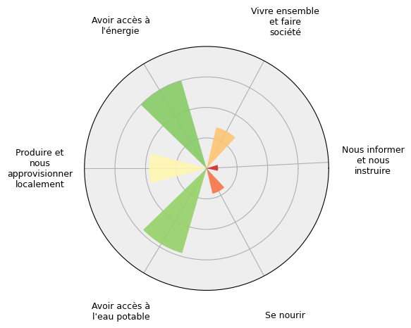

## Besoins vitaux

Besoins physiologiques et sanitaires dont la survie de l’être humain dépend. Abraham Maslow les présente comme socle de sa pyramide : me nourrir, avoir accès l’eau, avoir un toit, me soigner, me sentir en sécurité.

### Avoir accès à l'eau potable

L’accès à l’eau correspond à ses usages de base, en premier lieu les usages domestiques (boisson, préparation et cuisson des aliments, hygiène corporelle, hygiène générale et propreté du domicile ou du lieu de vie), mais aussi les activités industrielles, l’agriculture, la production d’électricité et le refroidissement des centres électriques, etc. Pour répondre à ces divers besoins et activités, des prélèvements d’eau sont réalisés dans les milieux. Pour quelques usages spécifiques, comme le refroidissement, les usagers peuvent recourir à de l’eau saumâtre ou salée, mais dans la majorité des cas, c’est de l’eau douce qui est prélevée. La majorité (autour de 90%) des prélèvements d’eau est restituée aux milieux naturels, hormis la partie évaporée ou absorbée par les individus ou la biosphère, mais souvent avec une qualité altérée et une modification du régime des eaux. Les prélèvements ont donc des impacts sur l’état quantitatif et qualitatif des eaux.

L’eau se révèle actuellement la première ressource naturelle affectée par des conflits d’usage en France, dans un contexte de raréfaction liée au dérèglement climatique. Les enjeux de transformation et de soutenabilité dans nos usages de l’eau sont déterminants pour notre résilience collective.

L’accès à l’eau comme droit fondamental est reconnu par la législation. En France, ce droit est reconnu par la loi du 30 décembre 2006 qui affirme que « l’usage de l’eau appartient à tous et chaque personne physique, pour son alimentation et son hygiène, a le droit d’accès à l’eau potable dans des conditions économiquement acceptables par tous ». La quantité minimale d’eau nécessaire pour couvrir les usages domestiques est définie entre 50 et 100 litres d’eau par personne et par jour.

La directive européenne n°2020/2184, dite directive « eau potable » a imposé aux États-membres de mettre en œuvre « les mesures nécessaires pour améliorer ou préserver l’accès de tous aux eaux destinées à la consommation humaine, en particulier les groupes vulnérables et marginalisés ». Enfin, la loi du 10 février 2020 relative à la lutte contre le gaspillage et à l’économie circulaire (AGEC) rappelle aussi que « les établissements recevant du public sont tenus d'être équipés d'au moins une fontaine d'eau potable accessible au public, lorsque cette installation est réalisable dans des conditions raisonnables. »

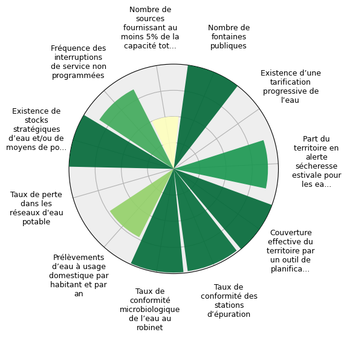

## Besoins essentiels

Besoins indispensables pour la vie en société. Ils correspondent aux tranches intermédiaires et supérieures de la pyramide de Maslow : m’informer et m’instruire, vivre ensemble et faire société, avoir accès à la nature.

### Nous informer et nous instruire

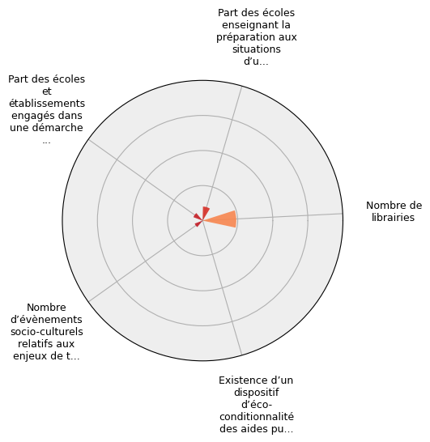